# Fama-French Factor Performance

Roger J. Bos, CFA

2020-11-12

Fama-French Monthly 5 Factor Returns

### Full Period 1963 - 2019

| Size | Value | Investment | Profitability | Momentum |
| --- | --- | --- | --- | --- |
| 0.72 | 0.87 | 0.89 | 0.89 | 1.9 |

### By Decade

| Decade | Size | Value | Investment | Profitability | Momentum |
| --- | --- | --- | --- | --- | --- |
| 1960 | 2.74 | 0.69 | -0.17 | 0.37 | 1.3 |
| 1970 | 1.39 | 2.32 | 1.82 | -0.16 | 0.34 |
| 1980 | -0.1 | 1.73 | 1.66 | 1.4 | 2.46 |
| 1990 | -0.6 | -0.01 | -0.01 | 0.72 | 3.68 |
| 2000 | 2.03 | 2.32 | 1.95 | 2.45 | -0.51 |
| 2010 | -0.12 | -0.69 | 0.07 | 0.39 | 3.78 |
| 2020 | -3.88 | -15.3 | -3.76 | 0.98 | 3.79 |

### By Year

| Year | Size | Value | Investment | Profitability | Momentum |
| --- | --- | --- | --- | --- | --- |
| 1963 | -3.33 | 1.45 | -0.94 | 1.54 | 3.82 |
| 1964 | 0.07 | 2.56 | 1.75 | -0.75 | 3.35 |
| 1965 | 5.9 | 1.71 | -0.89 | -0.1 | 2.91 |
| 1966 | 0.97 | -0.22 | -0.14 | -0.11 | -3.8 |
| 1967 | 10.42 | -1.26 | -3.34 | 1.76 | 6.36 |
| 1968 | 6.46 | 4.19 | 3.42 | -2.87 | 2.59 |
| 1969 | -4.35 | -3.22 | -1.41 | 3.71 | -4.89 |
| 1970 | -3.15 | 6.21 | 6.89 | -0.64 | -1.18 |
| 1971 | 1.75 | -2.68 | -1.45 | 2.33 | 3.38 |
| 1972 | -2.88 | 0.67 | -0.59 | 1.87 | 3.51 |
| 1973 | -6.84 | 6.47 | 2.52 | -3.49 | -7.68 |
| 1974 | 0.14 | 3.22 | 8.27 | -1.57 | -10.76 |
| 1975 | 4.35 | 2.23 | 0.07 | -0.01 | 8.31 |
| 1976 | 4.62 | 5.62 | 1.8 | -1.55 | 5.79 |
| 1977 | 6.71 | 2.09 | -0.07 | 0.52 | -2.24 |
| 1978 | 4.21 | -0.3 | 0.96 | 1.52 | 0.73 |
| 1979 | 5.01 | -0.33 | -0.23 | -0.6 | 3.57 |
| 1980 | 1.56 | -5.84 | -2.61 | 3.17 | 5.86 |
| 1981 | 2.26 | 6.71 | 2.84 | -0.43 | -4.73 |
| 1982 | 1.75 | 2.78 | 4.09 | -1.02 | 3.17 |
| 1983 | 2.87 | 4.5 | 3.68 | 0.09 | 3.62 |
| 1984 | -2.44 | 5.43 | 1.05 | 4.34 | -1.38 |
| 1985 | -0.08 | 0.05 | -0.79 | 2.62 | 6.31 |
| 1986 | -2.77 | 2.33 | 2.45 | 1.96 | 3.05 |
| 1987 | -2.64 | -1.07 | 1.78 | 1.78 | 0.29 |
| 1988 | 1.63 | 3.5 | 2.27 | 0.84 | 3.13 |
| 1989 | -3.1 | -1.05 | 1.79 | 0.66 | 5.24 |
| 1990 | -4.42 | -3.39 | -0.19 | 2.54 | -3.53 |
| 1991 | 3.47 | -3.22 | -3.3 | 2.56 | 7.47 |
| 1992 | 2.47 | 6.05 | 1.74 | 1.8 | 1.77 |
| 1993 | 1.7 | 4.29 | 3 | -1.8 | 2.29 |
| 1994 | -0.69 | -0.33 | 1.12 | 1.74 | -1.02 |
| 1995 | -1.8 | 1.37 | 0.6 | 0.29 | 7.63 |
| 1996 | -0.55 | 1.76 | -0.02 | 3.74 | 4.28 |
| 1997 | -1.5 | 4.2 | 1 | 2.15 | 6.75 |
| 1998 | -6.94 | -2.69 | -1.49 | 0.58 | 5.71 |
| 1999 | 2.3 | -8.1 | -2.61 | -6.39 | 5.5 |
| 2000 | 1.65 | 11.95 | 10.1 | 6.35 | -4.76 |
| 2001 | 7.06 | 4.7 | 2.77 | 4.26 | -3.95 |
| 2002 | 2.01 | 3.12 | 5.4 | 6.76 | -6.72 |
| 2003 | 5.15 | 0.86 | 3.46 | -4.49 | 7.94 |
| 2004 | 1.99 | 1.98 | -1.89 | 1.85 | 3.02 |
| 2005 | -0.05 | 2.49 | -1.37 | 0.33 | 0.95 |
| 2006 | 0.61 | 2.93 | 2.02 | 0.95 | 2.86 |
| 2007 | -2.23 | -4.91 | -2.19 | 1.28 | 0.4 |
| 2008 | 1.83 | 0.9 | 1.61 | 6.57 | -12.76 |
| 2009 | 2.32 | -0.84 | -0.42 | 0.65 | 7.91 |
| 2010 | 3.54 | -1.08 | 2.6 | -0.55 | 5.16 |
| 2011 | -1.3 | -2.32 | -0.23 | 3.73 | 0.49 |
| 2012 | 0.02 | 2.45 | 2.25 | -1.5 | 4.53 |
| 2013 | 1.67 | 0.62 | 0.31 | -0.85 | 8.91 |
| 2014 | -1.95 | -0.46 | -0.52 | 0.3 | 3.31 |
| 2015 | -1.64 | -2.96 | -2.59 | 0.15 | 0.26 |
| 2016 | 2.54 | 5.51 | 2.49 | 0.99 | 3.78 |
| 2017 | -1.4 | -3.28 | -2.86 | 1.23 | 5.65 |
| 2018 | -1.39 | -3.01 | 0.02 | -0.6 | -1.69 |
| 2019 | -1.25 | -2.4 | -0.76 | 0.98 | 7.39 |
| 2020 | -3.88 | -15.3 | -3.76 | 0.98 | 3.79 |

#### Average Performance of all 5 Factors w.r.t the Yield Curve

We segment the Fama-Frech 5 factor performance based on yield curve changes of 5 basis points or more during the month, ignoring any months in which the yield curve changed by less than 5 basis points. We also segment the time period into early (before 1990), middle (1990 to 2007), and recent (since mid-2009). Recent performance does seem to be different from that of before the great financial crisis (GFC).

| GFC | Yield.Curve | mean(value) |
| --- | --- | --- |
| Early (Pre 1990) | Flattens > 5 bps | 0.89 |
| Early (Pre 1990) | Steepens > 5 bps | -2.84 |
| Early (Pre 1990) | NA | 6.02 |
| Recent (Post GFC) | Flattens > 5 bps | -0.55 |
| Recent (Post GFC) | Steepens > 5 bps | 1.36 |
| Recent (Post GFC) | NA | 1.3 |

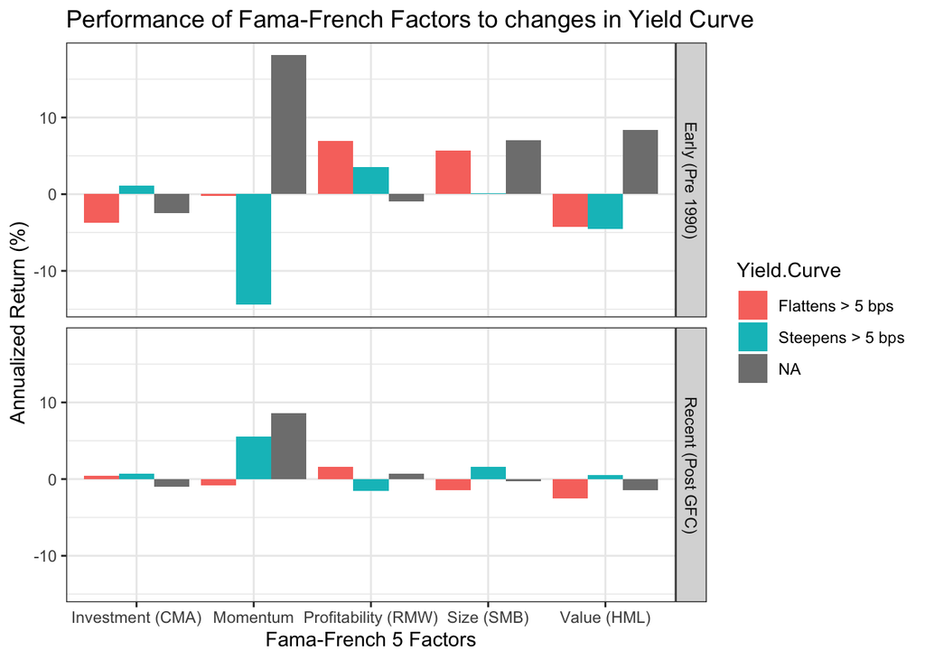

#### Average Performance of all 5 Factors w.r.t the Economic Regime

We segment the Fama-Frech 5 factor performance based on Economic Regime according to the following rules (defined at the bottom of the page):

| Economic Regime | Growth Indicator | Inflation Indicator |
| --- | --- | --- |
| Expansion | > 0 | > 0 |
| Slowdown | <= 0 | > 0 |
| Contraction | <= 0 | <= 0 |
| Recovery | > 0 | <= 0 |

| GFC | Regime | mean(value) |
| --- | --- | --- |
| Early (Pre 1990) | 1 Expansion | -0.58 |
| Early (Pre 1990) | 2 Slowdown | -1.17 |
| Early (Pre 1990) | 3 Contraction | -0.37 |
| Recent (Post GFC) | 1 Expansion | 1.68 |
| Recent (Post GFC) | 2 Slowdown | -0.88 |
| Recent (Post GFC) | 3 Contraction | -0.38 |
| Recent (Post GFC) | 4 Recovery | 0.79 |

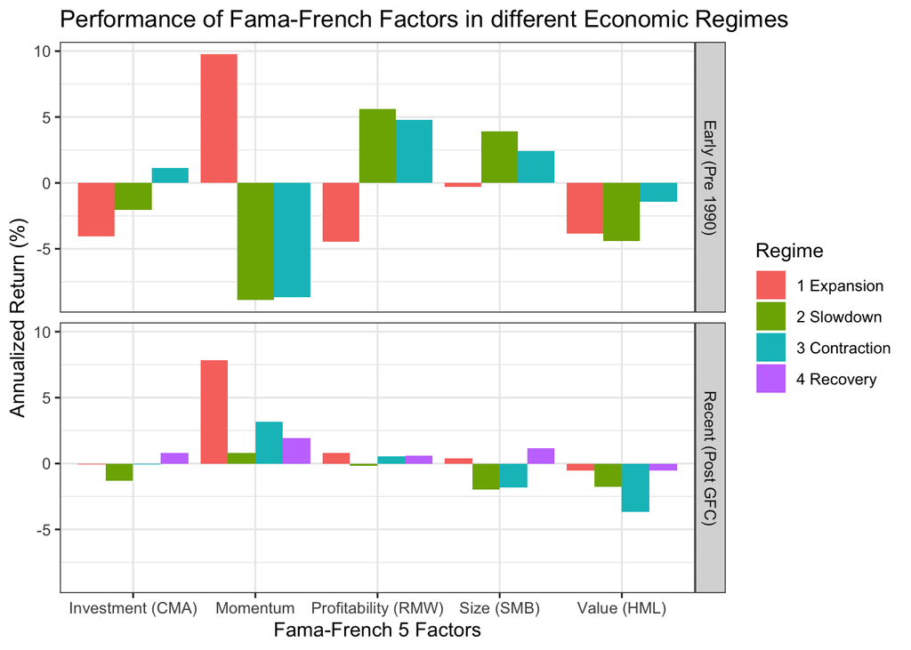

#### Average Performance of all 5 Factors w.r.t Canary Momentum since 2008

[This paper](https://papers.ssrn.com/sol3/papers.cfm?abstract_id=3212862) by Keller and Keunig describes using two equity ETFs (VWO and BND) as canary assets to determine when to move to cash in a tactical (defensive) asset allocation system. In this section we test this idea using the Fama-Frech 5 factors in the subsequent month from when the momentum was measured. We calculate the average 1M, 3M, 6M, and 12M volatility-adjusted momentum for VMO and BND. There are three posibilities, both ETFs have positive momentum, both have negative momentum, or one has positive momentum and the other has negative momentum. We notice that the momentum factor does much better when both canary assets are positive. Also, profitability, which is a quality factor, does best when both canary assets are negative. Since this factor is based on ETFs, we only have data back to 2008. We see that value has been weak for that entire period, no matter what the canary assets were indicating.

| Canary | mean(value) |
| --- | --- |
| 0 Both Positive | 1.15 |
| 1 One Negative | -0.24 |
| 2 Both Negative | -0.41 |

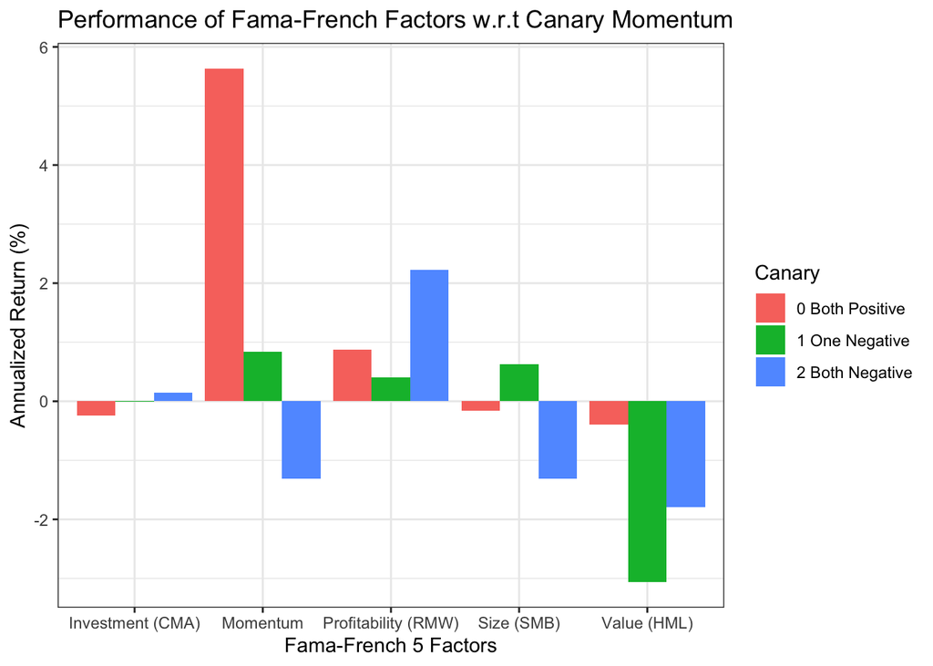

Notes: Pre-GFC is from January 1990 - December 2007. Post-GFC is from July 2009 - Present.

Sources:

The Fama-French factors can be downloaded from the [Kenneth R. French Data Library](https://mba.tuck.dartmouth.edu/pages/faculty/ken.french/).

The slope of the yield curve is measured by the spread between the 10-year and 2-year Treasury yields, FRED data codes T10Y2YM and T10Y2Y.

The growth indicator is defined as the ISM PMI minus 50 standardized plus the three month change in the ISM PMI standardized. The ISM PMI is from Quandl, code “ISM/MAN_PMI”.

The inflation indicator is defined as the average three month average minus the three year average of the CPI, FRED data code CPIAUCSL.